# Part II - ProsperLoans Data

## by Aibangbee O. Darlington

## Investigation Overview

> This Data analysis is aimed at investigation the ProsperLoan Dataset on loan applications and find insights to answer questions like:
> - What factors play a role in a loans Status?
> - What determines the amount of Borrower Annual Percentage Rate or interest rate charged on a loan?
> - And tries to see the difference between loans based on amount of loan applied for and Term of Loan

## Dataset Overview

> This data set contains 113,937 loans with 81 variables on each loan, including loan amount, borrower rate (or interest rate), current loan status, borrower income, and many others.

### LoanStatus:

> - Most of the Loans that are Current, Completed, Cancelled or are making final payments (FinalPaymentsInProgress) have on the average, lower Interest rates. Loans that are Past due, Defaulted or Charged off have on the average higher Interest rates. The average interest rates for LoanStatus that are past due are slightly higher with higher past due days. With Past Due(>120 days) having the highest mean Interest Rate.
> - Loan Term plays a huge role with Loan Status. A great amount(89%) of the Short Term loan payments. have Completed Status. Compared to only 38% of Medium Term and only 9% of Long Term Loans. We see that the shorter the Term the more likely the loan is completed, Medium term loans are the most likely to be defaulted or Charged Off and Long Term loans are the most likely to have due payments followed by Medium Term Loans.
> - The Loan Status is likely to be completed or Current when they are rated AA or A and we know that high CreditRange plays a role in being rated high(AA or A) in prosper ratings (alpha).

```
Most of the Loans that are Current, Completed or are making final payments (FinalPaymentsInProgress) have on the average, lower Interest rates. Loans that are Past due, Defaulted or Charged off have on the average higher Interest rates.
```

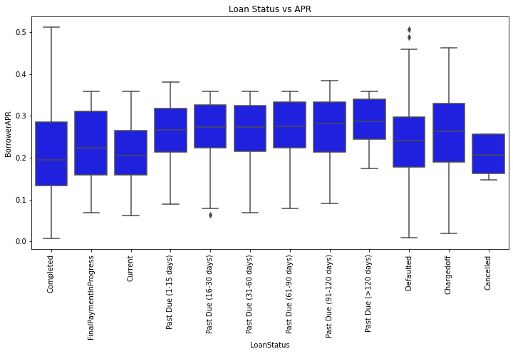

[output not shown]

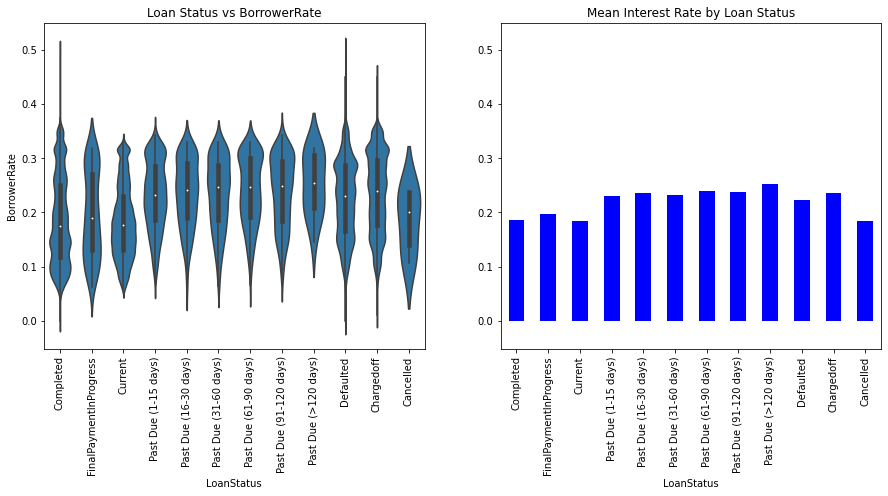

```
Here we see the likelyhood of a loan being completed or not defaulting to increase with higher ProsperLoan Rating(ProsperLoan Rating is mostly higher with high Credit Score Rating).
```

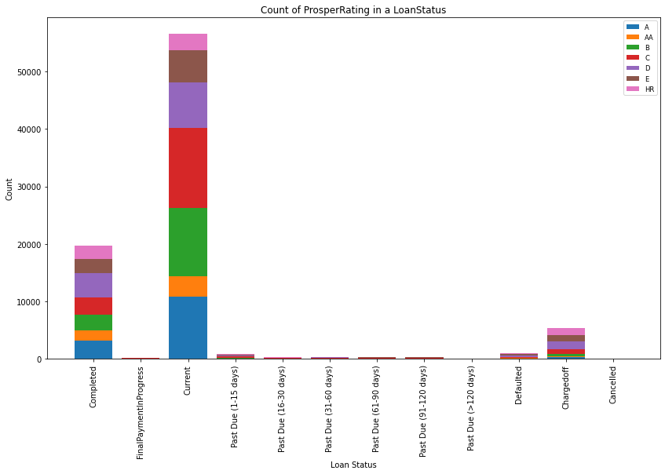

## BorrowerRate

> **Borrower Rate:** The Borrower Rate were mostly significantly affected by factors like:
> > - **CreditRange:** Negatively Correlated.The higher the CreditScore the lower the interest rates charged on loans
> > - **Loan Term:** There was slightly lower rates for short term loans, medium term and Long Term have almost similar rates.
> > - **Income Range:** slightly negative correlation. The higher the range the lower the interest charged(potentially low risk with higher income)
> > - **Debt To Income Ratio:** slightly positive correlation. We see that the higher the Debt to income ratio the higher the interest rates charged on the loan(High Debt-To-Income-Ratio is high risk).

```
Higher Credit Scores mean lower interest rate on loans and even lower interest rates if the loan term is shorter as can be seen in the plot below
```

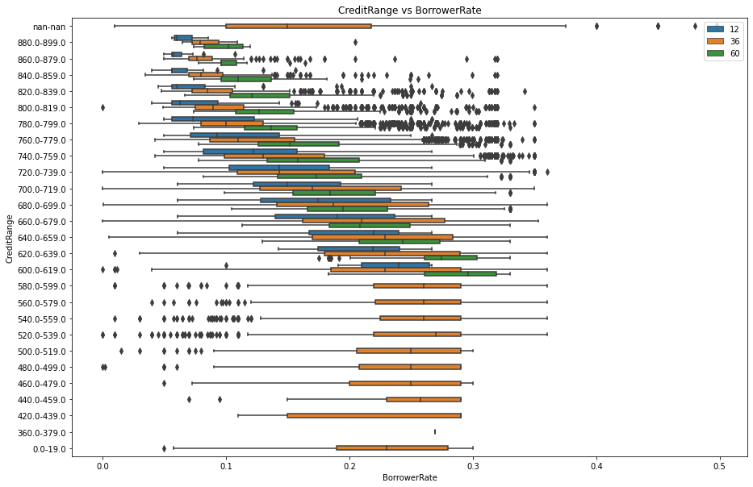

```
We see a positive weak correlation between Debt-To-Income Ratio and BorrowerRate
```

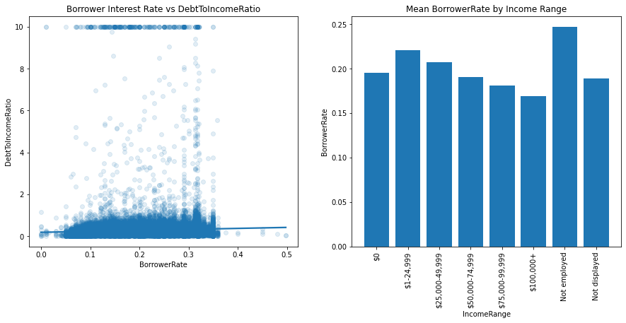

```
The average borrower rate seemed to reduce with higher income
```

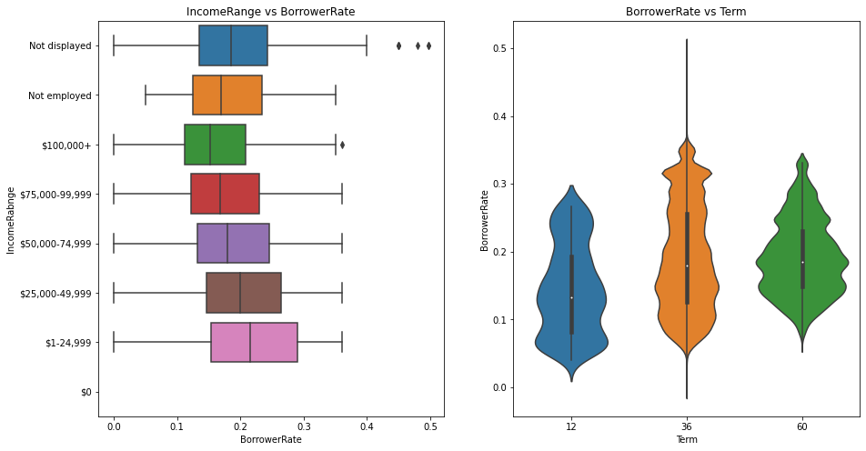

>   > **Note:** On further investigation i discovered ProsperLoans offices on their website had Texas and California addresses. Most likely company presence and more effective ad campaigns played a role here
> - Most of the Loans were taken for Debt Consolidation, Home Improvement and Business in decreasing order of frequency.

```
Loans were mostly from California, Texas, New York, Florida, Illinois and Georgia respectively
```

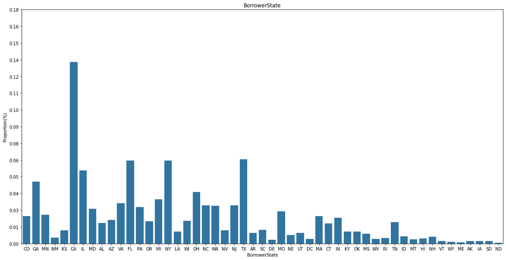

```
We see a huge amount of loans taken for Debt Consolidation
```

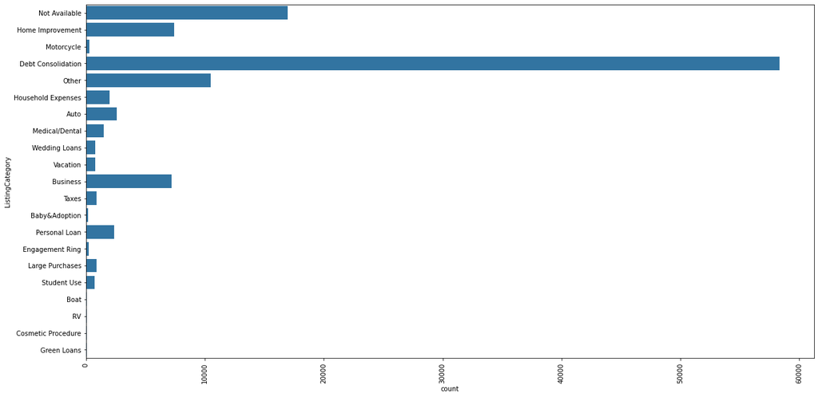